# How Popular is Your Music

Jonathan Lu, Carrie Wang, Zixuan Wang, Kara Wong

12/11/2019

# Abstract

# Introduction

In today’s day and age, every one uses some music streaming platform whether it be Spotify, Apple Music, or Google Play Music. Spotify[^1] is one of the more popular service with over 217 million active monthly users worldwide[^2]. For $9.99 a year, Spotify offers users unlimited access to its 50 million + songs library. While these numbers are impressive, it’s important to note that in 2018, the music industry topped $19 billion dollars in sales. Our initial interest in doing the analysis on this data set was due to its association with music and Spotify. However, we then realized that there could definitely be some monetary implications behind this analysis due to the sheer size of the music industry.

In a dystopian future of sorts, if a model could be trained well enough, newer artists could use it as a tool to break through the extremely gate-keeping nature of the music industry as a sort of proof-of-concept in regards to their style. Since this model is being built on nothing more than the acoustic qualities of the music, it could provide an unbiased view on whether or not a song / album could be popular. If it turns out that the album is predicted to underwhelm, artists could take the hint and add in filler songs that cater to the public in an attempt to draw more attention to their profile. Adding filler songs could also boost help the artists secure funding for their next venture. Given that there are two main sides to the music industry, the artists and the labels, the music labels could also use a model like this to increase their profits by focusing their advertisements on select artists, or picking up new artists that the model deems “popular”. While it seems extremely unlikely that a label would base all of their signings on a model, the model could provide them a baseline of sorts from which they can add more subjective observations.

For each song in its library, Spotify keeps track of its popularity, duration, acousticness, danceability, and many other acoustic qualities. While the algorithm by which Spotify calculates a song’s popularity is hidden from the general public, it’s loosely based on the amount of plays the song has recently. Spotify allows web developers and other users to query this information via their Web API[^3] which is how all the data for this dataset was accumulated.

In an attempt to construct a tool to predict song popularity based on their attributes, statistical learning techniques have been applied to song popularity data downloaded from Kaggle[^4]. The goal of this model would be to predict song popularity from song attributes for the reasons outline above. The results show even the best models built on this data failed to predict the popularity of a song. However, further improvements to these models could be explored by the addition of characteristics other than just acoustic ones.

# Methods

## Data

For the purpose of this analysis, `song_name` information is eliminated because it is not a relevant feature used in the prediction. Eliminating `song_name` speeds up calculation. In preparation for model training, a training dataset is created using 80% of the provided data，while the rest of the data is considered as testing data. Within the training dataset, an estimation dataset is created using 80% of the training dataset, and the remaining is constructed as validation data.

Some exploratory data analysis can be found in the appendix.

## Modeling

In order to predict the popularity of songs, two modeling techniques were considered: linear models and tree-based models. Specifically, a simple linear model with all available features, a linear model with significant features, a generalized regression model using 5-fold crossvalidation, a random forest model from `randomForest` package, a ridge regression model, and an Xgboost model are used.

- A simple linear model using all available features fit to the estimation data.

```r
set.seed(42)
lm_1 = train(song_popularity ~ .,
             data = song_trn,
             method = "lm",
             trControl = cv_trn_5)
```

- A linear regression with reduced features fit to estimation data.

```r
set.seed(42)
lm_2 = train(song_popularity ~ tempo + danceability + instrumentalness +
               liveness + loudness + audio_valence,
             data = song_trn,
             method = "lm",
             trControl = cv_trn_5)
```

- A generalized linear model using 5-fold cross validation fit to estimation dataset.

```r
set.seed(42)
mod_glm = train(song_popularity ~ ., data = song_trn,
                     method = "glm",
                     metric = "RMSE",
                     trControl = cv_trn_5)
```

- A random forest model used for regression from the `randomForest` package fit to the estimation data.

```r
set.seed(42)
rf_mod = randomForest(song_popularity ~ .,
                      data = song_trn,
                      trControl = cv_trn_5)
```

```r
lambdas = 10^seq(3, -2, by = -.1)

set.seed(42)
glmnet_mod = train(song_popularity ~ .,
                   data = song_trn,
                   method = "glmnet",
                   trControl = cv_trn_5,
                   tuneGrid = expand.grid(alpha = 0, lambda = seq(0.001, 2, by = 0.001)))
```

- An XGBoost model using the `caret` package fit to the estimation data, using 5-fold crossvalidation.

```r
parametersGrid = expand.grid(eta = c(.1, .2, .3),
                            colsample_bytree = c(0.5,0.7),
                            max_depth = c(3,6),
                            nrounds = 100,
                            gamma = 1,
                            min_child_weight = 2,
                            subsample = 1)

set.seed(42)
xgb_mod = train(song_popularity ~ ., data = song_trn,
                      method = "xgbTree",
                      trControl = cv_trn_5,
                      tuneGrid = parametersGrid,
                      tuneLength = 2)
```

Models selection and evaluation is discussed in the results section.

## Evaluation

To evaluate the ability to predict song_popularity, the data was split into training and testing sets. Cross-validated training errors have been reported in this section. Our best model has been selected based on the lowest root mean-squared error; we found the best model to be our random forest model.

| Model | Validation RMSE |
| --- | --- |
| Simple Linear | 21.44 |
| Reduced Linear | 21.44 |
| Random Forest | 17.06 |
| Ridge Regression | 21.44 |
| XGBoost | 19.14 |

# Results

The table below shows the result of song_popularity predictions on the test data using a random forest model fit to the training data.

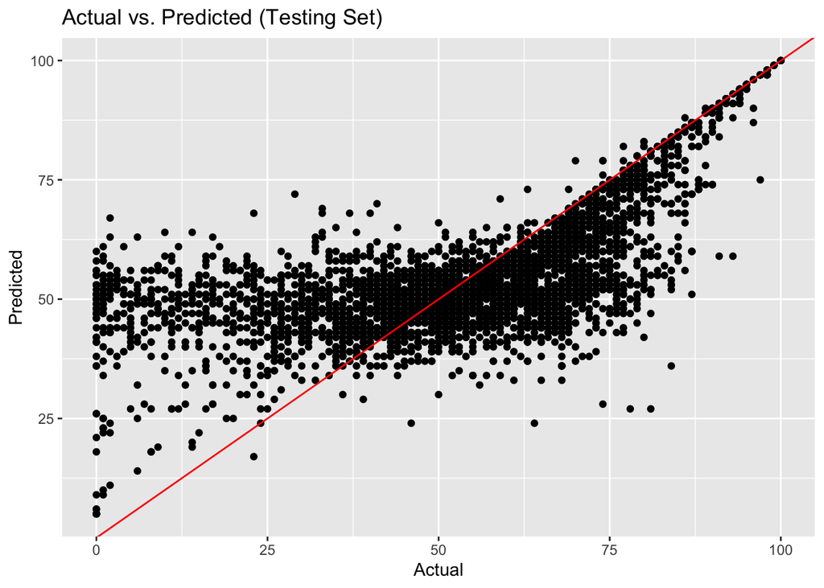

| Model | Test RMSE |
| --- | --- |
| Random Forest Model | 16.9 |

# Discussion

For someone using this model to determine if they should invest in an artist’s song production, we see that our model would steer someone to fund a project that would actually have low success while not allocating that money into some of the songs that would actually be more popular. Given these errors, it should be noted that this model is not particularly useful in predicting song popularity. It can be improved in the following aspects. First, more data could be included to further investigation. Second, class imbalance problem should be addressed in the future. For example, a potential solution could be picking data from different popularity ranges. Let’s say, 0-20, 20-40, 40-60, 60-80, 80-100, respectively. Then, subsampling an equal amount of data for each range. These ranges could also be further explored, and have one range be 0-50 to denote a classification of “unpopular songs” being less than 50. We can expect that a classification as such would have a much higher accuracy rate than our current regression.

We strongly recommend additional research to be conducted before implementing our model for its intended use.

# Appendix

## Data Dictionary

- `song_popularity`: A value between 0 and 100, with 100 being the most popular. Calculated by Spotify’s algorithm based on total number of plays the track has had and how recent those plays are
- `song_duration`: track length in milliseconds
- `acousticness`: 0.0 to 1.0 confidence measure on how acoustic the track is, 1 representing high confidence
- `danceability`: describes how suitable a track is for dancing based on tempo, rhythm stability, beat strength, and overall regularity; 0.0 being least danceable and 1.0 most danceable
- `energy`: 0.0 to 1.0 representing perceptual measure of intensity and activity
- `instrumentalness`: 0.0 to 1.0, with 1.0 reflecting that the song contains close to no vocals
- `key`: overall key of the track; integers map to pitches using standard Pitch Class notation
- `liveness`: detects the presence of an audience in the recording
- `loudness`: overall loudness of a track in decibels
- `audio_mode`: indicates the modality (major or minor) of the track
- `speechiness`: detects presence of spoken words in the track; i.e. the more the track is like a talk show, the closer this metric is to 1.0
- `tempo`: overall estimated tempo of a track in beats per minute
- `time_signature`: an estimated number of how many beats are in each bar or measure
- `audio_valence`: describes the musical positiveness conveyed by the track

For additional information, see documentation on Kaggle.[^7]

## EDA

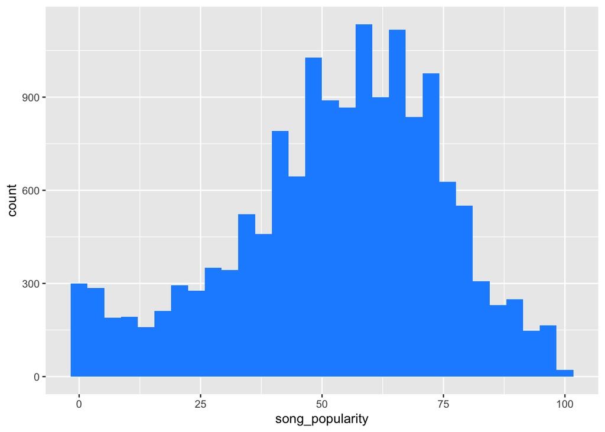

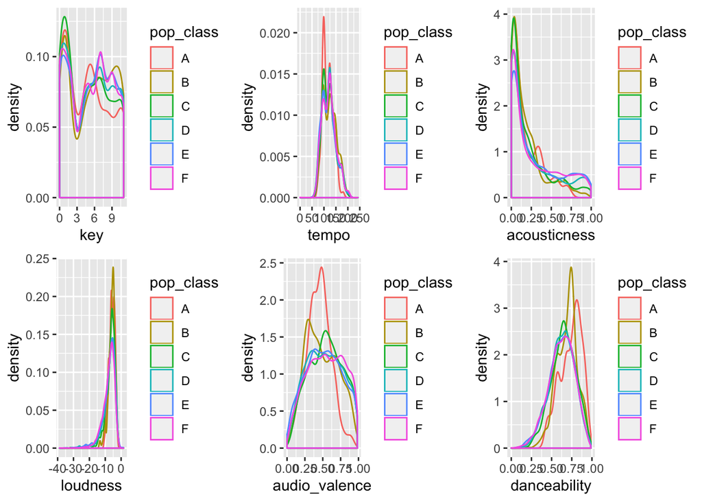

[^1]: [Wikipedia: Spotify](https://simple.wikipedia.org/wiki/Spotify)
[^2]: [Spotify Growth numbers](https://www.theverge.com/2019/4/29/18522297/spotify-100-million-users-apple-music-podcasting-free-users-advertising-voice-speakers)
[^3]: [Spotify: API](https://developer.spotify.com/documentation/web-api/reference/tracks/get-audio-features/)
[^4]: [Kaggle: 19,000 Spotify Songs](https://www.kaggle.com/edalrami/19000-spotify-songs)
[^5]: [Kaggle: 19,000 Spotify Songs](https://www.kaggle.com/edalrami/19000-spotify-songs)
[^6]: [Spotify: API](https://developer.spotify.com/documentation/web-api/reference/tracks/get-audio-features/)
[^7]: [Kaggle: 19,000 Spotify Songs](https://www.kaggle.com/edalrami/19000-spotify-songs)